# leaf_flower_pollen

Yi

2023-07-03

# 1. leaf flower start date realtion in NPN

## 1.1 genus level correlation

```r
source("scripts/plot_rlm_combined_8genuses.R") # after libaray mass, dplyr::select is masked
```

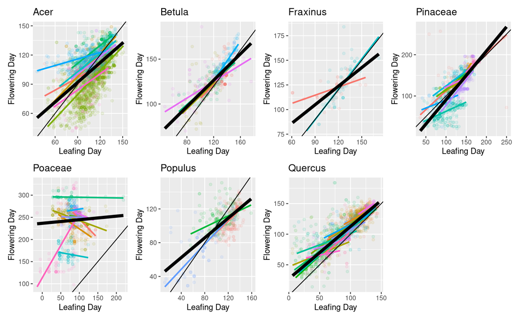

```r
combined_plot
```

Fig.1 Leaf and flowering day relationship of pollen allergy related genus. Each dot represents a individual in a year. Each color represent a species. The wide black line represents the total dots robust linear regression. The thin black line is the 1:1 line.

## 1.2 species level correlation

```r
species_stat
```

```
## # A tibble: 62 × 5
##        n slope intercept scientific_name common_name
##    <int> <dbl>     <dbl> <chr>           <chr>
##  1  3148 0.675     31.2  Acer            <NA>
##  2    46 0.425     58.4  <NA>            bigleaf maple
##  3   164 0.813     24.6  <NA>            boxelder
##  4  1747 0.822      5.32 <NA>            red maple
##  5   316 0.617     55.8  <NA>            striped maple
##  6   544 0.625     46.5  <NA>            sugar maple
##  7   129 0.224     95.8  <NA>            vine maple
##  8    99 0.601     46.2  <NA>            Norway maple
##  9   103 0.553     34.3  <NA>            silver maple
## 10   578 0.736     38.1  Betula          <NA>
## # ℹ 52 more rows
```

```r
# write_csv(species_stat, "data/figure1_stat.csv")
rm(list = ls())
```

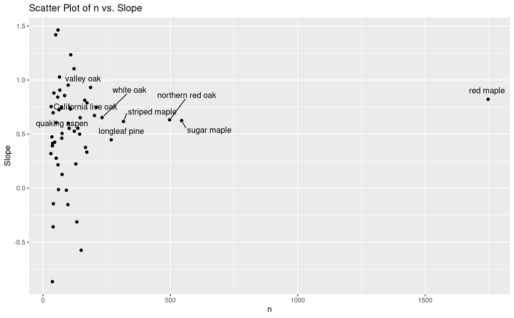

```r
source("scripts/plot_species_observation_slope.R")
observation_slope
```

```r
rm(list = ls())
```

Figure S1: relationship between number of observations and the leaf-flower linear model slope

Most species has positive relationship between leaf and flower. From this table and figure, we can see as we have more observations (more robust result), the slope is more between 0.5-1 (check those species). More close to 1 slope means leaf and flower has more sync change in both rate and direction.

Let’s disentangle the species in acer and oak

## 1.3 oak species and acer species

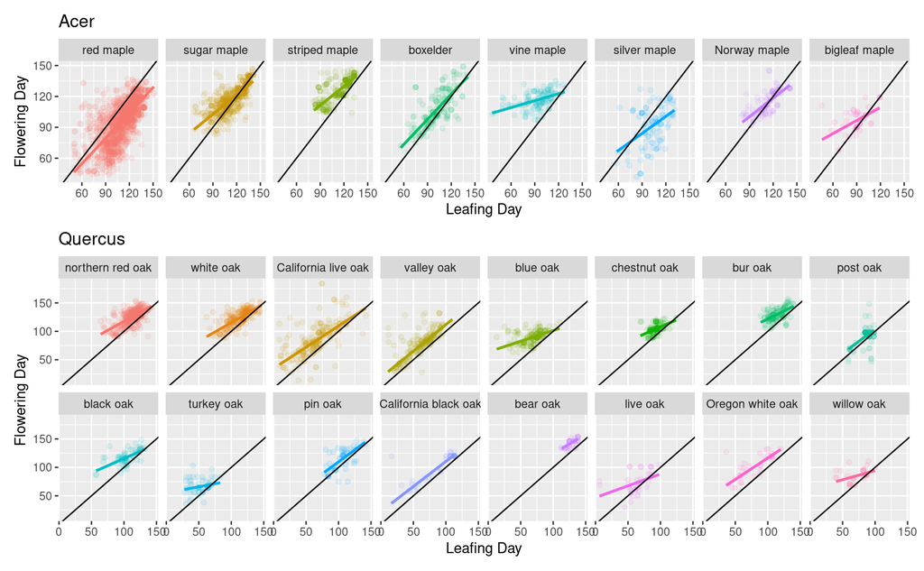

```r
source("scripts/plot_maple_oak_species.R")
combined_plot
```

```r
# rm(list = ls())
```

Figure 2: species level leaf-flower relationship. In each genus, species are arranged from most observation to least observation

From acer, we can see that red maple has a large window for both leafing and flowering while other species has a relative later and shorter window. Most of them leaf, no matter leaf first or flower first, has closely related leaf and flower time. Vine maple is a little special relative small flower variability than leaf may be related to (1) garden plants, human management (2) short shrub (refer to grass has flower-leaf not well related)

Together, most of them has a slope ~ 1 (leaf flower change at similar rate and direction). But most are smaller than 1 rather than larger than 1 which means leafing time change is greater than flowering change (variability).

Let’s see whether this reflects different sensibility of leaf and flower to environment change: if we consider warming tem and earlier events, leaf first (oak) will show an increasing lag, while flower first will show decrease lag (red maple). Since oaks are more consistent order, we use oak as an example to show environment change’s effect.

# 2. different sensitivity of flower and leaf to climate change

## 2.1 download winter spring temperature

```r
# source("scripts/download_daymetwinsprtem_for_q.R")
```

## individual temporal change

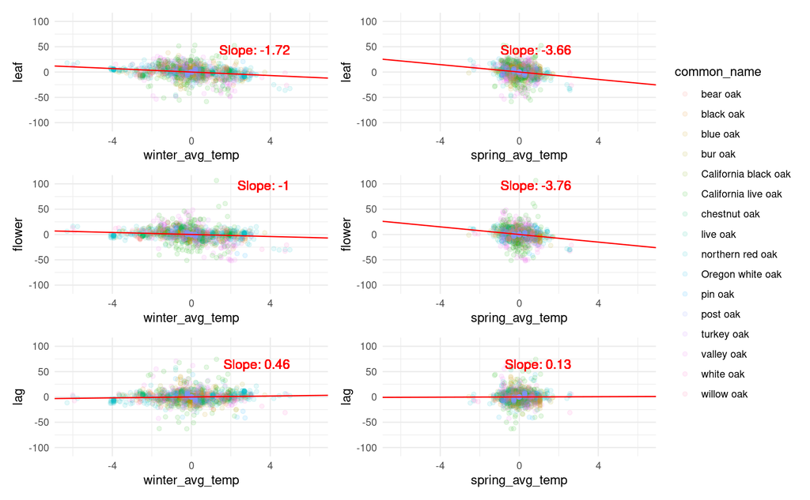

```r
source("scripts/plot_individual_oak_norm.R")
plot_individual_varibility
```

```r
rm(list = ls())
```

Figure 3. Phenology’s response to climate change reflected on inter-year climate varibility. Each dot is a individual-year. Each individual is recentered based on it’s multiple-year average. So this figure shows the inter-year variblity of climate’s impact on the same individual. We stack the individuals together to show a general trend. The red line is the linear model with intercept = 0 means no phenology change if no climate change (assumption).

From this figure we can see: 1. As tem increase (no matter winter or spring), leaf and flower will advance. 2. winter temperature has larger varibility than spring temperature. 2. Both leaf and flower has a high sensitivity to spring tem change but less sensitivity to large winter tem change. 3. Leaf is more sensitive to winter temperature, so lag is bigger with increasing tem (leaf before flower). They have almost same sensitivity to spring tem so the lag’s response to spring tem is tiny.

## 2.2 individual spatial change

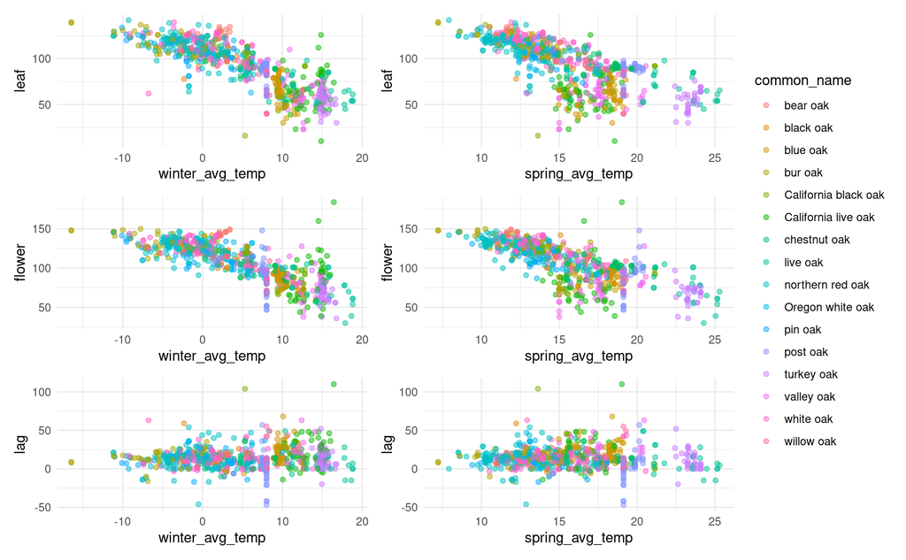

```r
source("scripts/plot_oak_spatial_compare.R")
plot_spatial_varibility
```

```r
rm(list = ls())
```

Figure 4. Phenology’s response to climate change reflected on spatial distribution. Each dot is an indiviudal.

We can see that 1. as moving to a warmer area, both leaf and flower will advance, but the trend is more dominant by species shift (sf2 to see intra-species trend) 2. as moving to warmer area, species composition is changing. therefore the spatial trend is not extendable because of the distribution limitation. 3. warmer area has a higher variability while phenology time at colder area is more constrained

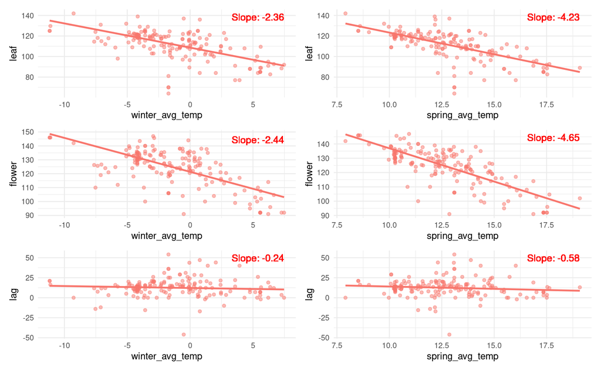

```r
source("scripts/plot_spatial_northredoak.R")
plot_spatial_northernredoak
```

```r
rm(list = ls())
```

SF 2. Northern red oak’s phenlogy response to climate reflected on spatial distribution.

Interesting! Unlike one individual multiple year change, here we see that growing to in a warmer area has slight more impact on flower than leaf which cause a slight decrease in lag (leaf before flower).

# 3. using npn to predict pollen

From those analysis we can see that leaf and flower mostly change synchronourly. The winter and spring temperature’s impact on the lag between flower and leaf is tiny. Thus, using a fixed lag to use leaf to predict flower further pollen is plausible feasible. Here we use a sample study to show this.

similar super good: 2017 0.014835547 0.016191712 67e7f6ab-b262-45a0-b592-e71cbf433b2f similar average good: 2016 0.031382947 0.039839431 6261714f-e5ae-41ef-96a7-0b1c108256a2 similar super bad: 2017 0.067786149 0.055293799 d22bab5b-768e-4bcc-a70f-8ebe9ef7cb4d

with leaf only, but leaf good: 2020 0.013496487 NA fd742905-ee8d-4184-8543-23029fc676b1

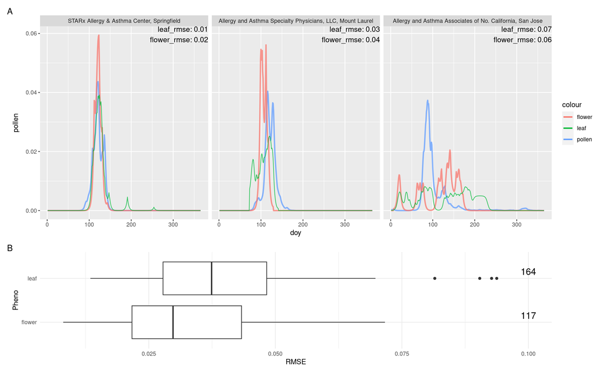

```r
source("scripts/plot_threeexamples_boxplotrmse.R")
three_examples_boxplot
```

From this figure we can see that flower and leaf has similar prediction accuracy of pollen. But we have more spatial coverage and more frequent observation for leaf which can increase polle prediction, specially for places without pollen observation.